# STAT 413/613 HW 2: stringr and lubridate

Ifebunandu Jerome Okeke

2021-02-04

# Instructions

Rename the starter file under the analysis directory as `hw_02_yourname.Rmd` and use it for your solutions.  
1. Modify the “author” field in the YAML header.  
2. Stage and Commit R Markdown and HTML files (no PDF files).  
3. **Push both .Rmd and HTML files to GitHub**.  
- Make sure you have knitted to HTML prior to staging, committing, and pushing your final submission.  
4. **Commit each time you answer a part of question, e.g. 1.1**  
5. **Push to GitHub after each major question**, e.g., Scrabble and Civil War Battles  
- **Committing and Pushing are graded elements for this homework.**  
6. When complete, submit a response in Canvas

- Only include necessary code to answer the questions.
- Most of the functions you use should be from the tidyverse. Too much base R will result in point deductions.
- Use Pull requests and or email to ask me any questions. If you email, please ensure your most recent code is pushed to GitHub.
- Learning objectives:
  - Manipulate dates and times with lubridate.

# 1 Scrabble Words

For this exercise, we are using the [Collins Scrabble Words](https://en.wikipedia.org/wiki/Collins_Scrabble_Words), which is most commonly used outside of the United States. The dictionary most often used in the United States is the [Tournament Word List](https://en.wikipedia.org/wiki/Official_Tournament_and_Club_Word_List).

**WARNING**: Do not try `str_view()` or `str_view_all()` on these data.It will stall your computer.

1. Use a readr function to load the 2015 list of Collins Scrabble Words into R from your data folder or from https://data-science-master.github.io/lectures/data/words.txt
   - (note: “NA” is an official Scrabble word).

```r
library(tidyverse)
words = read_table("https://data-science-master.github.io/lectures/data/words.txt")
head(words)
```

```
## # A tibble: 6 x 1
##   word
##   <chr>
## 1 AA
## 2 AAH
## 3 AAHED
## 4 AAHING
## 5 AAHS
## 6 AAL
```

2. What are the six longest words that have the most “X”’s in them?

# 2 Ans:

```r
words %>%

  filter(str_detect(word, "X")) %>%

  mutate(Num_X = str_count(word, "X")) %>%

  mutate(word_length = str_count(word)) %>%

  arrange(desc(Num_X), word_length) ->

  longest_X_words
```

[output not shown]

3. How many words have an identical first and second half of the word? If a word has an odd number of letters, exclude the middle character.
- MURMUR counts because MUR is both the first and second half.
- JIGAJIG counts because the middle A is excluded so JIG is both the first and second half.
- Save the results to a variable.

# 3 Ans:

```r
words %>%

  mutate(count = str_count(word)) %>%

  mutate(first_half = substring(word, 1, floor(str_count(word)/2))) %>%

  mutate(second_half = substring(word, ceiling(str_count(word)/2 +1), str_count(word))) %>%

  filter(first_half == second_half) ->

  identical_words

  count(identical_words)
```

```
## # A tibble: 1 x 1
##       n
##   <int>
## 1   254
```

**-** There are 254 words that has an identical first and second half.

4. Use the results from 3 to find the longest word with an identical first and second half of the word?

# 4 Ans:

```r
identical_words %>%

  arrange(desc(count)) ->

  longest_word

head(longest_word)
```

```
## # A tibble: 6 x 4
##   word         count first_half second_half
##   <chr>        <int> <chr>      <chr>
## 1 CHIQUICHIQUI    12 CHIQUI     CHIQUI
## 2 CHINACHINA      10 CHINA      CHINA
## 3 MANGEMANGE      10 MANGE      MANGE
## 4 MINGIMINGI      10 MINGI      MINGI
## 5 QUINAQUINA      10 QUINA      QUINA
## 6 EINSTEINS        9 EINS       EINS
```

**-** The longest word with an identical first and second half of the word is CHIQUICHIQUI.

# 5 Civil War Battles

The data in “civil_war_theater.csv” contains a information on American Civil War battles, taken from [Wikipedia](https://en.wikipedia.org/wiki/List_of_American_Civil_War_battles).

Variables include:

- `Battle`: The name of the battle.
- `Date`: The date(s) of the battle in different formats depending upon the length of the battle.
  - If it took place on one day, the format is “month day, year”.
  - If it took place over multiple days, the format is “month day_start-day_end, year”.
  - If it took place over multiple days and months, the format is “month_start day_start - month_end day_end, year”.
  - If it took place over multiple days,months, and years, the format is “month_start day_start, year_start - month_end day_end, year_end”.
- `State`: The state where the battle took place. Annotations (e.g. describing that the state was a territory at the time) are in parentheses.
- `CWSAC`: A rating of the military significance of the battle by the Civil War Sites Advisory Commission. `A` = Decisive, `B` = Major, `C` = Formative, `D` = Limited.
- `Outcome`: Usually `"Confederate victory"`, `"Union victory"`, or `"Inconclusive"`, followed by notes.
- `Theater`: An attempt to to identify which theater of war is most associated with the battle
1. Use a readr function and relative paths to load the data into R.

```r
cv_war <- read_csv(file="./../data/civil_war_theater.csv")
```

The next several questions will help you take the dates from all the different formats and create a consistent set of start date and end date variables in the data frame. We will start by calculating how many years, and months are in each battle.

2. Add a variable to the data frame with the number of years for each battle.
- Create a character variable as follows. This can be used as a pattern in a regular expression.
- Use `year_regex` to now count the number of years in each battle, add this to the data frame, and save the data frame.

# 6 Ans:

```r
library(lubridate)
year_regex = str_c(1861:1865, collapse = "|")

year_regex
```

```
## [1] "1861|1862|1863|1864|1865"
```

```r
cv_war %>%

  mutate(yr_count = str_count(Date, year_regex)) %>%

  arrange(desc(yr_count)) ->

  cv_war_yr_count
```

3. Add a variable to the data frame with the number of months for each battle.
- Consider R’s built-in vector of month names: `month.name`.
- Use `month.name` to count the number of month names in the `Date` variable in each battle.
- Add this to the data frame. (You might need to do something similar to what we did in part 2).

#Ans:

```r
Months <- month.name

Months
```

```
##  [1] "January"   "February"  "March"     "April"     "May"       "June"
##  [7] "July"      "August"    "September" "October"   "November"  "December"
```

```r
month_regex = str_c(Months, collapse = "|")

month_regex
```

```
## [1] "January|February|March|April|May|June|July|August|September|October|November|December"
```

```r
cv_war_yr_count %>%

  mutate(month_count = str_count(Date, month_regex)) %>%

  arrange(desc(month_count)) ->

cv_war_yr_month_count
```

4. Add a variable to the data frame that is `TRUE` if `Date` spans multiple days and is `FALSE` otherwise. Spanning multiple months and/or years also counts as `TRUE`.

#Ans:

```r
cv_war_yr_month_count %>%

  mutate(multi_days = str_detect(Date, "-")) %>%

  arrange(desc(multi_days)) ->

  cv_multi_days
```

5. Make four new data frames by filtering the data based on the length of the battles:
   - a data frame with the data for only those battles spanning just one day,
   - a data frame with the data for only those battles spanning multiple days in just one month,
   - a data frame with the data for only those battles spanning multiple months but not multiple years, and,
   - a data frame with the data for only those battles spanning multiple years.

# 7 Ans:

**-** Battles for one day.

```r
cv_multi_days %>%

  filter(multi_days == FALSE) ->

  cv_one_day
```

**-** Battles spanning multiple days in just one month

```r
cv_multi_days %>%

  filter(multi_days == TRUE) %>%

  filter(month_count == 1) ->

  cv_multi_days_one_month
```

**-** Battles spanning multiple months but not multiple year

```r
cv_multi_days %>%

  filter(multi_days == TRUE) %>%

  filter(month_count != 1) %>%

  filter(yr_count == 1) ->

  cv_multi_months_one_yr
```

**-** Battles spanning multiple years

```r
cv_multi_days %>%

  filter(multi_days == TRUE) %>%

  filter(yr_count != 1) ->

  cv_multi_yrs
```

6. For each of the four new data frames,
- Add two new variables:
  - `Start` should contain the start-date of each battle.
  - `End` should contain the end-date of each battle.
  - Hint: look at help for `separate()`
  - Make sure these are `Date` class objects.
- Remove the `Date` variable from each data frame.
- Save the data frames with the new variables

# 8 Ans:

**-** New one day data

```r
cv_one_day %>%

  separate(Date, into = c("Start", "End"), sep = "-") %>%

  mutate(Start = mdy(Start)) %>%

  mutate(End = Start) %>%

  dplyr:: select(Battle, State, Start, End, CWSAC, Outcome) %>%

  arrange(State) ->

  new_one_day_data
```

# 9 New multiple days in one month data

```r
cv_multi_days_one_month %>%

  separate(Date, into = c("StartMonthDay", "EndDayYear"), sep = "-") %>%

  separate(StartMonthDay, into = c("Month", "StartDay")) %>%

  separate(EndDayYear, into = c("EndDay", "Year")) %>%

  mutate(Start = paste(Month, StartDay, Year), End = paste(Month, EndDay, Year)) %>%

  mutate(Start = mdy(Start), End = mdy(End)) %>%

  arrange(State) %>%

  dplyr:: select(Battle, State, Start, End, CWSAC, Outcome) ->

  new_days_one_month_data
```

# 10 New data for battles spanning multiple months but not multiple year

```r
cv_multi_months_one_yr %>%

  separate(Date, into = c("StartMonthStartDay", "EndMonthEndDayYear"), sep = "-") %>%

  separate(EndMonthEndDayYear, into = c("EndMonthEndDay", "Year"), sep = ",") %>%

  mutate(Start = paste(StartMonthStartDay, Year), End = paste(EndMonthEndDay, Year)) %>%

  mutate(Start = mdy(Start), End = mdy(End)) %>%

  arrange(State) %>%

  dplyr:: select(Battle, State, Start, End, CWSAC, Outcome) ->

  new_multi_month_data
```

# 11 New data battles spanning multiple years

```r
cv_multi_yrs %>%

  separate(Date, into = c("Start", "End"), sep = "-") %>%

  mutate(Start = mdy(Start), End = mdy(End)) %>%

  dplyr:: select(Battle, State, Start, End, CWSAC, Outcome) ->

  new_multi_yr_data
```

7. Create a new data frame with all the battles and the Start and End dates by binding the rows of the four data frames as updated in part 6

# 12 Ans:

```r
combined_cv_data = rbind(new_one_day_data, new_days_one_month_data, new_multi_month_data, new_multi_yr_data) %>%
  arrange(State) ->

combined_cv_data
```

8. Calculate the number of days each battle spanned.
- What’s the longest battle of the war?
  - How long did it last?

# Ans:

  ```r
  combined_cv_data %>%

  mutate(Days = End - Start) ->

  combined_cv_duration
  ```

# 13 Longest battle

```r
combined_cv_duration %>%

  filter(Days == max(Days)) %>%

  dplyr::select(Battle, Days)
```

```
## # A tibble: 1 x 2
##   Battle               Days
##   <chr>                <drtn>
## 1 Siege of Port Hudson 49 days
```

**-** The longest battle is Siege of Port Hudson and it lasted for 49 days.

9. Is there an association between the CWSAC significance of a battle and its duration?
- Create an appropriate plot.
- Interpret the plot in one sentence to answer the question.
- Extra Credit: Test for a linear relationship using `lm()` and interpret the results in one sentence based on the $p$-value and adjusted R-squared.

# 14 Ans:

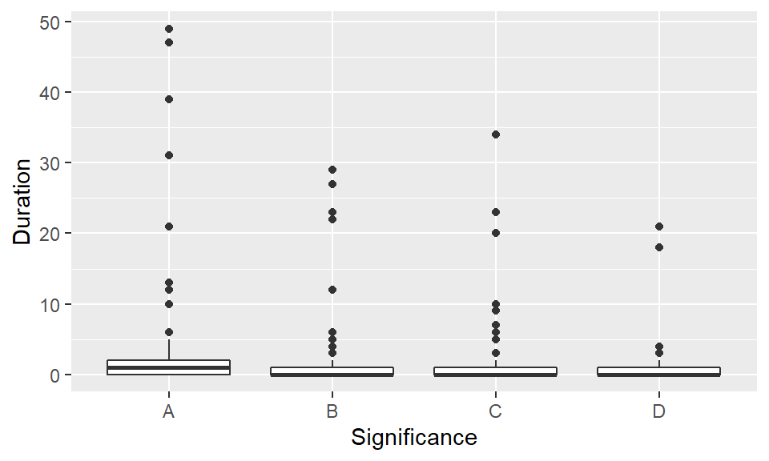

```r
ggplot( combined_cv_duration, aes(x = as.factor(CWSAC), y = Days)) +

  geom_boxplot() +

  geom_smooth(method = "lm", formula = y ~ as.factor(x), se = F) +

  xlab("Significance") +

  ylab("Duration")
```

**-** From the plot above, we can see the that as the significance gets bigger, the duration of the battle tends to last longer. This tells us that there is a association between the CWSAC significance of a battle and its duration.

# 15 Test for linear relationship.

```r
lm_fit <- lm(as.numeric(Days, units = "days") ~ CWSAC, data = combined_cv_duration)

summary(lm_fit)
```

```
##
## Call:
## lm(formula = as.numeric(Days, units = "days") ~ CWSAC, data = combined_cv_duration)
##
## Residuals:
##    Min     1Q Median     3Q    Max
## -5.778 -1.808 -0.808 -0.680 43.222
##
## Coefficients:
##             Estimate Std. Error t value Pr(>|t|)
## (Intercept)   5.7778     0.8625   6.699 7.60e-11 ***
## CWSACB       -3.9701     1.0324  -3.845 0.000141 ***
## CWSACC       -4.3920     1.0038  -4.375 1.57e-05 ***
## CWSACD       -4.9907     1.0266  -4.861 1.71e-06 ***
## ---
## Signif. codes:  0 '***' 0.001 '**' 0.01 '*' 0.05 '.' 0.1 ' ' 1
##
## Residual standard error: 5.786 on 380 degrees of freedom
## Multiple R-squared:  0.0622, Adjusted R-squared:  0.0548
## F-statistic: 8.401 on 3 and 380 DF,  p-value: 2.026e-05
```

**-** Our model shows that all predictor variables are significant. The rating of the military significance of the battle by the civil war sites Advisory commission shows that for every one increase in a battle rated major(CWSACB) holding other variable constant, the duration of the battle reduces by 3.97 days. For every one increase in a battle rated formative(CWSACC) holding other variables constant, the duration of the battle decreases by 4.4 days and for every one increase in a battle rated Limited(CWSACD) holding other variable constant, the duration of the battle decreases by approximately 5 days . Also an $R^2$ of 6% signifies the variation of the model explained by the predictor variables.

10. Extra Credit: Did the theaters of war shift during the American Civil War?
- Reproduce this plot in R (filter out states with two or fewer battles.)
- Interpret the plot in one sentence.